# Progetto Laboratorio di Statistica

Lo stesso accade per i valori della variabile dipendente e i residui.

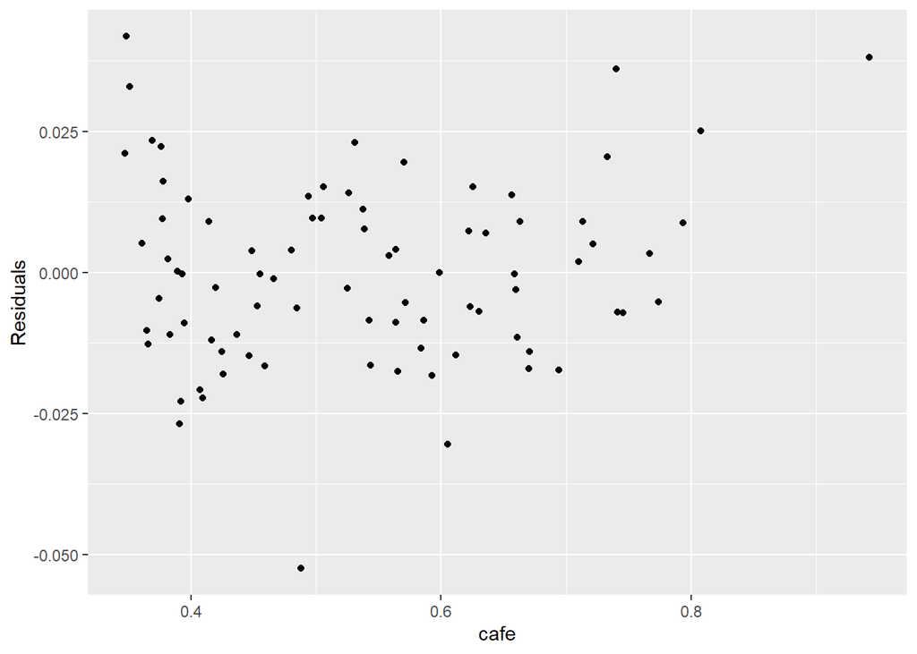

```r
ggplot(df, aes(x=cafe, y=Residuals)) +
geom_point()
```

**Previsioni con il modello di regressione**

Il training set viene utilizzato per addestrare il modello: ovvero, il modello impara dalle osservazioni nel training set e cerca di trovare i pattern o le relazioni tra le variabili che possano aiutarlo a fare previsioni su nuovi dati. Una volta che il modello è stato addestrato, viene testato utilizzando il test set. Il test set rappresenta una porzione separata del dataset complessivo, che non è stata utilizzata per addestrare il modello. Il modello utilizza i dati del test set per fare previsioni e valutare la sua capacità di generalizzazione, ovvero di fare previsioni accurate su nuovi dati. Per cui dopo aver stimato e addestrato il modello sul training set, è possibile utilizzare il test set per fare **previsioni ex-post**. La previsione ex-post implica l’utilizzo di dati per i predittori che sono stati osservati e che non sono stati utilizzati per la stima del modello.

```r
prev_m = cbind(gas=aus_mul_test[,2],
 permanent=c(aus_mul_test[,3]),
 resshort=c(aus_mul_test[,4]),
 wine=c(aus_mul_test[,1]))
prev_m = data.frame(prev_m)
prev <- forecast(mod5, newdata=prev_m)
caf_test<-data.frame(aus_mul_test[,7])
forecast::accuracy(prev, aus_mul_test[,7])[,c(2,3,5)]
```

```
##                    RMSE        MAE     MAPE
## Training set 0.01615403 0.01275834 2.578137
## Test set     0.04015193 0.03431902 4.088907
```

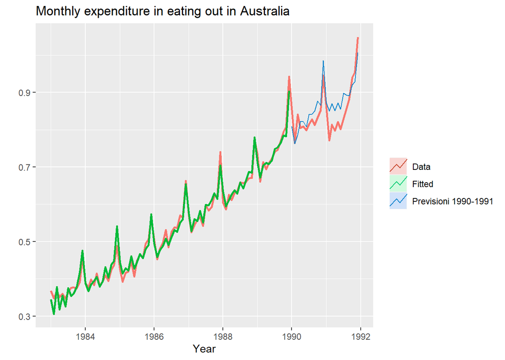

```r
autoplot(aus_mult[,7], series="Data", size=1) +
 autolayer(fitted(mod5), series="Fitted", size=1) +
autolayer(prev, series="Previsioni 1990-1991", PI = FALSE) +
 xlab("Year") + ylab("") +
 ggtitle("Monthly expenditure in eating out in Australia ") +
 guides(colour=guide_legend(title=" "))
```

## 5.3 Conclusioni circa i regressori e i modelli di regressione

In conlusione, sulla base dei risultati analizzati provenienti dai modelli di regressione implementati si può affermare che:

- Il miglior modello lineare non include tutte le variabili considerate ma solo **trend, season , gas, permanent, resshort e wine**.
- Come ci si aspettava:
  - c’è una relazione positiva tra il numero di cene e pranzi fuori e il numero di visitatori: se un luogo è frequentato da molti turisti o visitatori, è probabile che aumenti il numero di persone che scelgono di cenare o pranzare al di fuori di casa.
  - è esistende una relazione positiva tra il consumo di vino e il numero di cene e pranzi fuori: in genere, il consumo di vino è più comune durante i pasti fuori casa.
  - La relazione negativa tra il tasso di occupazione e il numero di cene e pranzi fuori si basa sull’idea che quando il tasso di disoccupazione è alto, le persone potrebbero essere meno inclini a spendere denaro per cenare o pranzare fuori casa. Questa ipotesi logica suggerisce che la disponibilità di reddito e la sicurezza lavorativa possono influenzare il comportamento di spesa delle persone. Quando ci sono meno opportunità di lavoro o incertezza economica, le persone tendono ad essere più prudenti nella spesa, riducendo quindi il numero di occasioni in cui scelgono di cenare o pranzare al di fuori del proprio domicilio. Tuttavia il modello migliore esclude questa variabile.